# Snow Data Assignment: Web Scraping, Functions, and Iteration

# Assignment:

## 1

Extract the meteorological data URLs. Here we want you to use the `rvest` package to get the URLs for the `SASP forcing` and `SBSP_forcing` meteorological datasets.

```r
site_url <- 'https://snowstudies.org/archived-data/'

#Read the web url
webpage <- read_html(site_url)

#Extract only weblinks and then the URLs!
links_met <- webpage %>%
  html_nodes('a') %>%
  .[grepl('forcing',.)] %>%
  html_attr('href')
```

## 2

Download the meteorological data. Use the `download_file` and `str_split_fixed` commands to download the data and save it in your data folder. You can use a for loop or a map function.

```r
#Grab only the name of the file by splitting out on forward slashes
splits_met <- str_split_fixed(links_met,'/',8)

#Keep only the 8th column
dataset_met <- splits_met[,8]

#generate a file list for where the data goes
file_names_met <- paste0('C:/Users/13074/Documents/ESS580/3_snow_functions_iteration/data',dataset_met)


#This for loop takes the links_met list and adds a destination to it.
for(i in 1:2){
  download.file(links_met[i],destfile=file_names_met[i])
}

downloaded_met <- file.exists(file_names_met)
```

## 3

Write a custom function to read in the data and append a site column to the data.

```r
# this code grabs the variable names from the metadata pdf file
library(pdftools)
headers <- pdf_text('https://snowstudies.org/wp-content/uploads/2022/02/Serially-Complete-Metadata-text08.pdf') %>%
  readr::read_lines(.) %>%
  trimws(.) %>%
  str_split_fixed(.,'\\.',2) %>%
  .[,2] %>%
  .[1:26] %>%
  str_trim(side = "left")

#headers

file_names_met[]
```

```
## [1] "C:/Users/13074/Documents/ESS580/3_snow_functions_iteration/dataSBB_SASP_Forcing_Data.txt"
## [2] "C:/Users/13074/Documents/ESS580/3_snow_functions_iteration/dataSBB_SBSP_Forcing_Data.txt"
```

```r
file <- file_names_met[1]

# Reads in the data
our_met_reader <- function(file){
  name = str_split_fixed(file,'_',5)[,5] %>%
    gsub('SP_Forcing_Data.txt','',.)
    df <- read_fwf(file) %>%
      setNames(headers) %>%
    mutate(siteID =name)

}
```

## 4

Use the `map` function to read in both meteorological files. Display a summary of your tibble.

```r
file_names_met
```

```
## [1] "C:/Users/13074/Documents/ESS580/3_snow_functions_iteration/dataSBB_SASP_Forcing_Data.txt"
## [2] "C:/Users/13074/Documents/ESS580/3_snow_functions_iteration/dataSBB_SBSP_Forcing_Data.txt"
```

```r
met_data_full <- map_dfr(file_names_met,our_met_reader)

head(met_data_full) %>%
  kable(.,'html') %>%
  kable_styling() %>%
  scroll_box(width='800px',height='300px')
```

| year | month | day | hour | minute | second | precip [kg m-2 s-1] | sw down [W m-2] | lw down [W m-2] | air temp [K] | windspeed [m s-1] | relative humidity [%] | pressure [Pa] | specific humidity [g g-1] | calculated dewpoint temperature [K] | precip, WMO-corrected [kg m-2 s-1] | air temp, corrected with Kent et al. (1993) [K] | air temp, corrected with Anderson and Baumgartner (1998)[K] | air temp, corrected with Nakamura and Mahrt (2005) [K] | siteID |
| --- | --- | --- | --- | --- | --- | --- | --- | --- | --- | --- | --- | --- | --- | --- | --- | --- | --- | --- | --- |
| 2003 | 11 | 10 | 1 | 0 | 0 | 0.0000000 | -9999 | -9999 | 270.135 | -9999 | 91.900 | 66863.46 | 4.189e-03 0 | 2000 | 3000 | 0 | 4009 | 0 | SA |
| 2003 | 11 | 10 | 2 | 0 | 0 | 0.0002778 | -9999 | -9999 | 269.923 | -9999 | 93.000 | 66863.46 | 4.172e-03 0 | 2000 | 3000 | 0 | 4009 | 0 | SA |
| 2003 | 11 | 10 | 3 | 0 | 0 | 0.0002778 | -9999 | -9999 | 269.707 | -9999 | 93.200 | 66863.46 | 4.114e-03 0 | 2000 | 3000 | 0 | 4009 | 0 | SA |
| 2003 | 11 | 10 | 4 | 0 | 0 | 0.0002778 | -9999 | -9999 | 269.552 | -9999 | 93.400 | 66863.46 | 4.075e-03 0 | 2000 | 3000 | 0 | 4009 | 0 | SA |
| 2003 | 11 | 10 | 5 | 0 | 0 | 0.0008333 | -9999 | -9999 | 269.467 | -9999 | 93.500 | 66863.46 | 4.053e-03 0 | 2000 | 3000 | 0 | 4009 | 0 | SA |
| 2003 | 11 | 10 | 6 | 0 | 0 | 0.0002778 | -9999 | -9999 | 269.392 | -9999 | 93.500 | 66863.46 | 4.030e-03 0 | 2000 | 3000 | 0 | 4009 | 0 | SA |

## 5

Make a line plot of mean temp by year by site (using the `air temp [K]` variable). Is there anything suspicious in the plot? Adjust your filtering if needed.

*Some of the sensors seemed to be offline during 2003-2004 which was affecting the temperature sensor. These years were filtered out.* *Air temperature across both Senator Beck and Swamp Angel sites show increases in temperature during the period of record. Similarity in temperature patterns are likely due to the sites’ proximity to each other.*

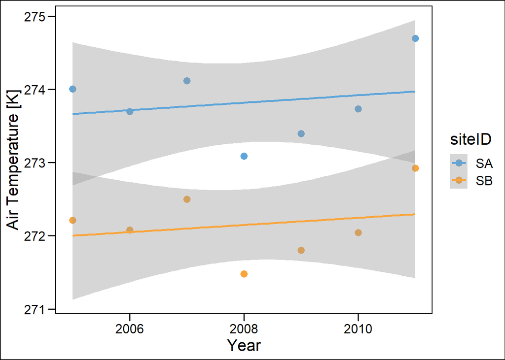

```r
mean_a_t_k <- met_data_full %>%
  rename(air_temp_K = "air temp [K]") %>%
  filter(year > 2004) %>%
  group_by(year,siteID) %>%
  summarize(mean_a_t_k = mean(air_temp_K,na.rm=T))

ggplot(mean_a_t_k,aes(x=year,y=mean_a_t_k,color=siteID)) +
  geom_point(size = 3) +
  theme_base() +
  scale_color_few() +
  geom_smooth(method=lm) +
  labs(x='Year', y="Air Temperature [K]")
```

## 6

Write a function that makes line plots of monthly average temperature at each site for a given year. Use a for loop to make these plots for 2005 to 2010. Are monthly average temperatures at the Senator Beck Study Plot ever warmer than the Snow Angel Study Plot? Hint: https://ggplot2.tidyverse.org/reference/print.ggplot.html

*Both Swamp Angel Senator Beck sites demonstrate temperature fluctuation typical of high elevation locations in the northern hemisphere. Similarity in temperature patterns are likely due to the sites’ proximity to each other.*

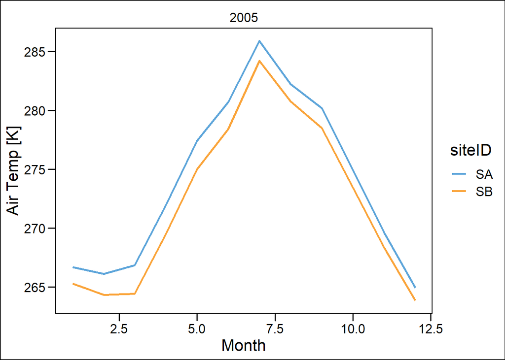

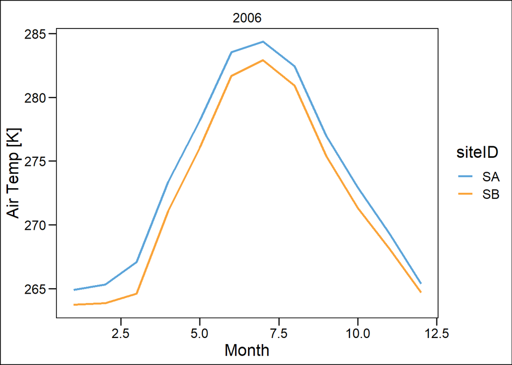

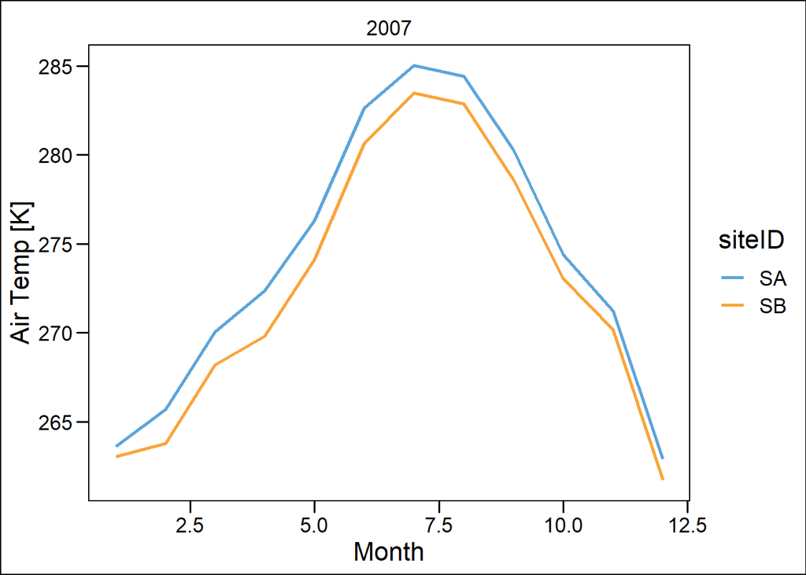

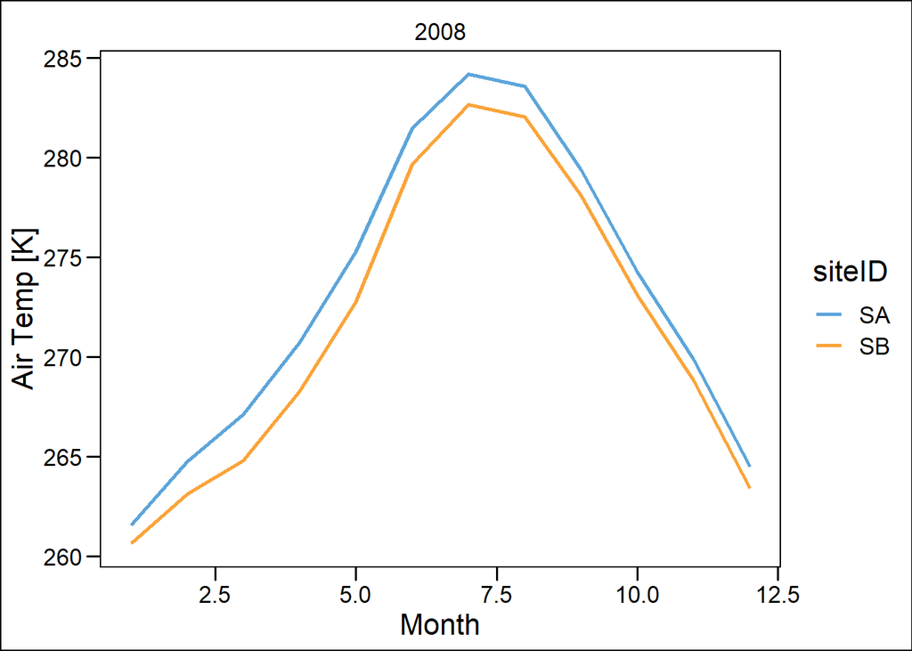

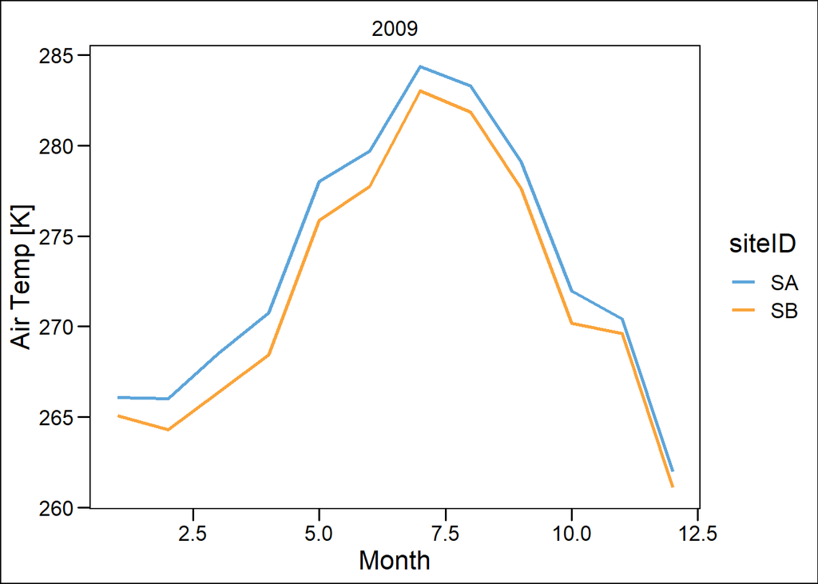

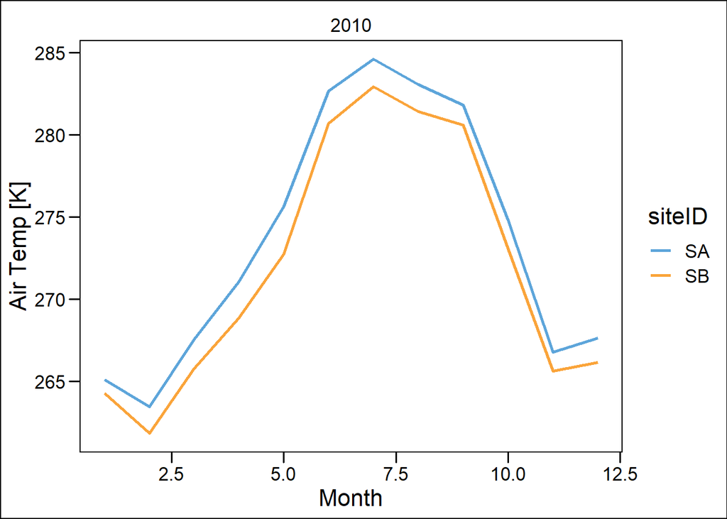

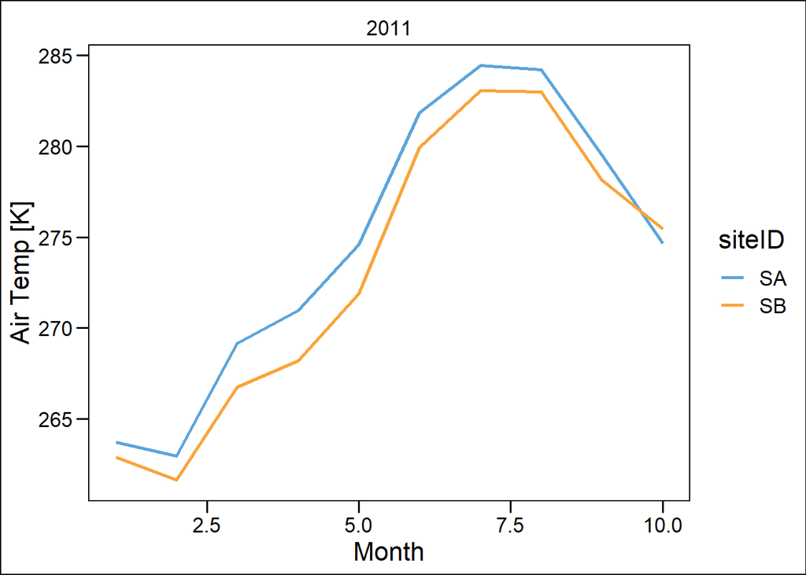

```r
plot_figure_k <- function(df, year) {
mean_month_a_t_k <- df %>%
  rename(air_temp_K = "air temp [K]") %>%
  mutate(month = month(month, label = FALSE)) %>%
  filter(yr == year) %>%
  group_by(year,month,siteID) %>%
  summarize(mean_a_t_k = mean(air_temp_K,na.rm=T))

figure_k <-
 ggplot(mean_month_a_t_k,aes(x=month,y=mean_a_t_k,color=siteID)) +
  geom_line(size = 1) +
  theme_base() +
  scale_color_few() +
  labs(x='Month', y="Air Temp [K]") +
  facet_wrap(~year)

print(figure_k)
}

years <- c(2005:2011)

for (yr in years){
  plot_figure_k(met_data_full, year)
}
```

# Bonus:

## Bonus 1

Make a plot of average daily precipitation by day of year (averaged across all available years). Color each site.

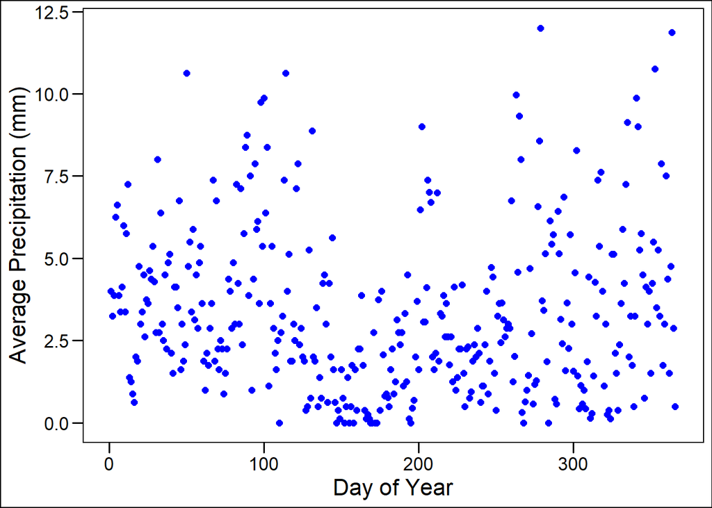

```r
precip <- met_data_full %>%
  mutate(date = make_date(year, month, day)) %>%
  mutate(date = as.Date(date))%>%
  mutate(doy = yday(date)) %>%
  rename(precip_unit_area = "precip [kg m-2 s-1]") %>%
  mutate(precip_mm = precip_unit_area*86400) %>%
  group_by(doy) %>%
  summarise(average_precip = mean(precip_mm))

ggplot(precip,aes(x=doy,y=average_precip)) +
  geom_point(size = 2, color="blue") +
  theme_base() +
  labs(x='Day of Year', y="Average Precipitation (mm)")
```

## Bonus 2

Use a function and for loop to create yearly plots of precipitation by day of year. Color each site.

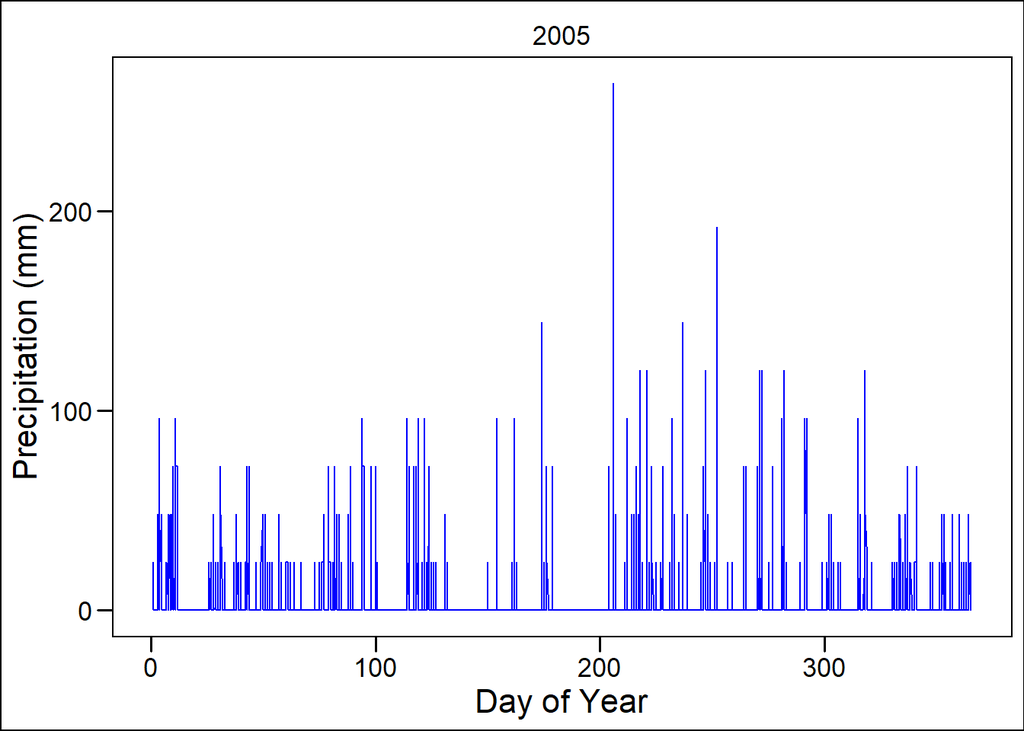

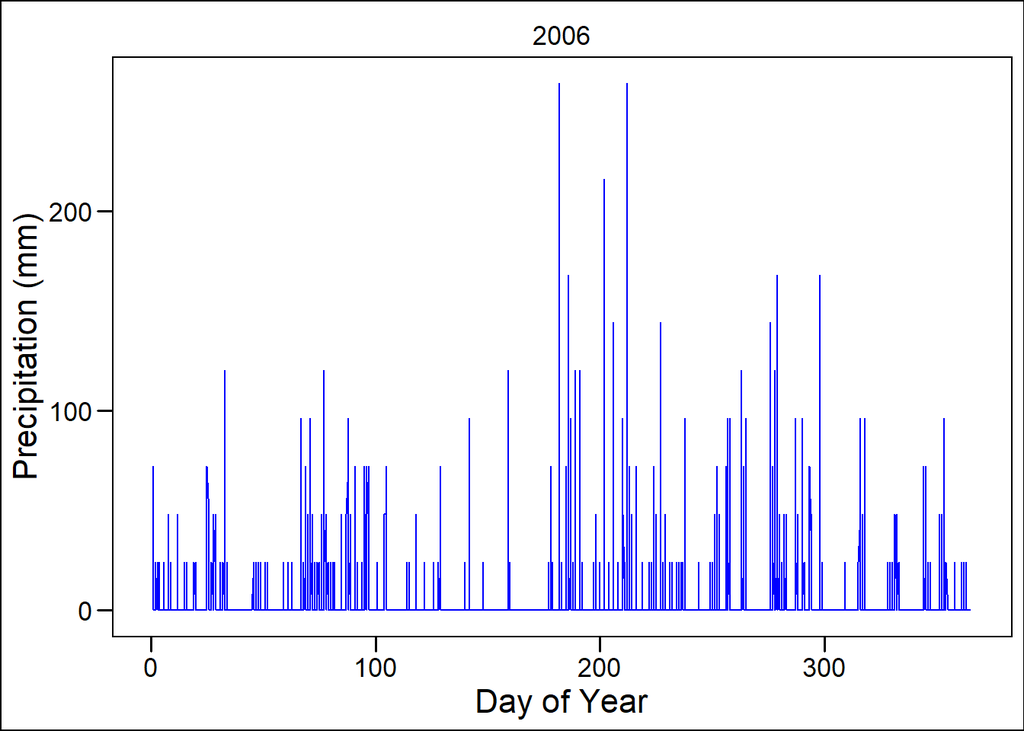

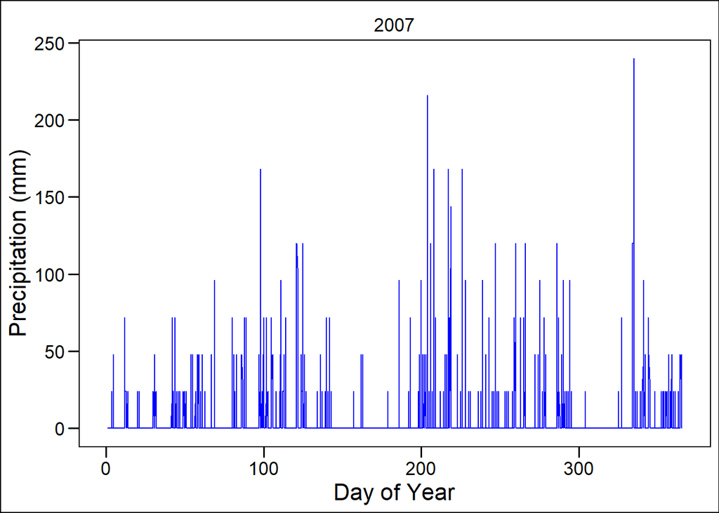

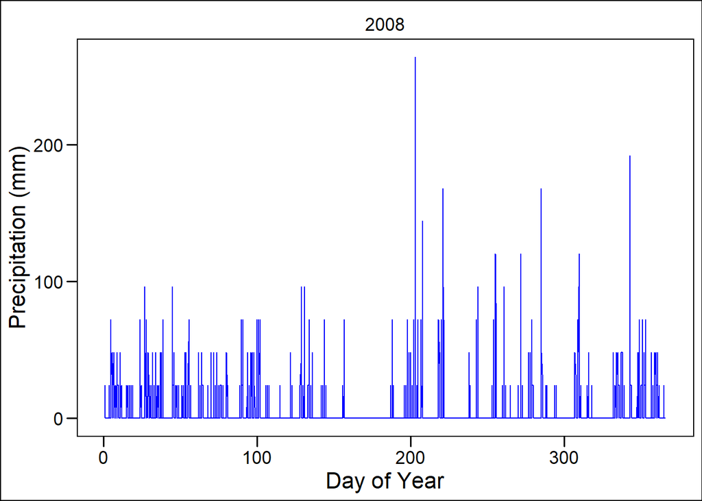

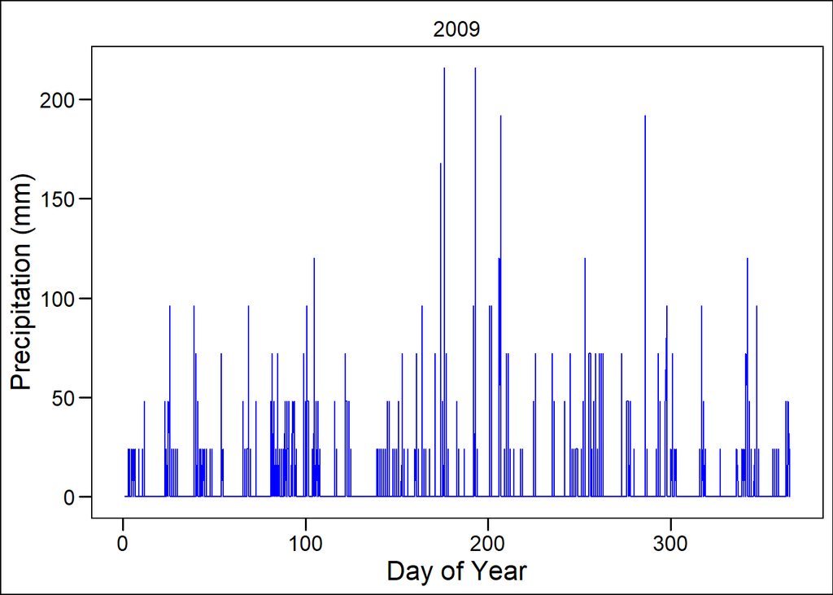

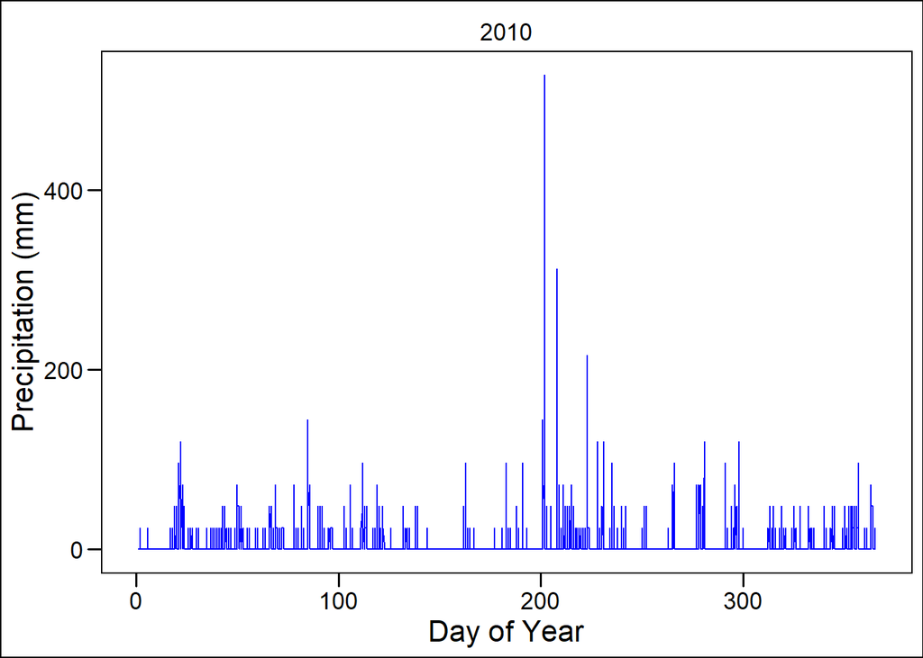

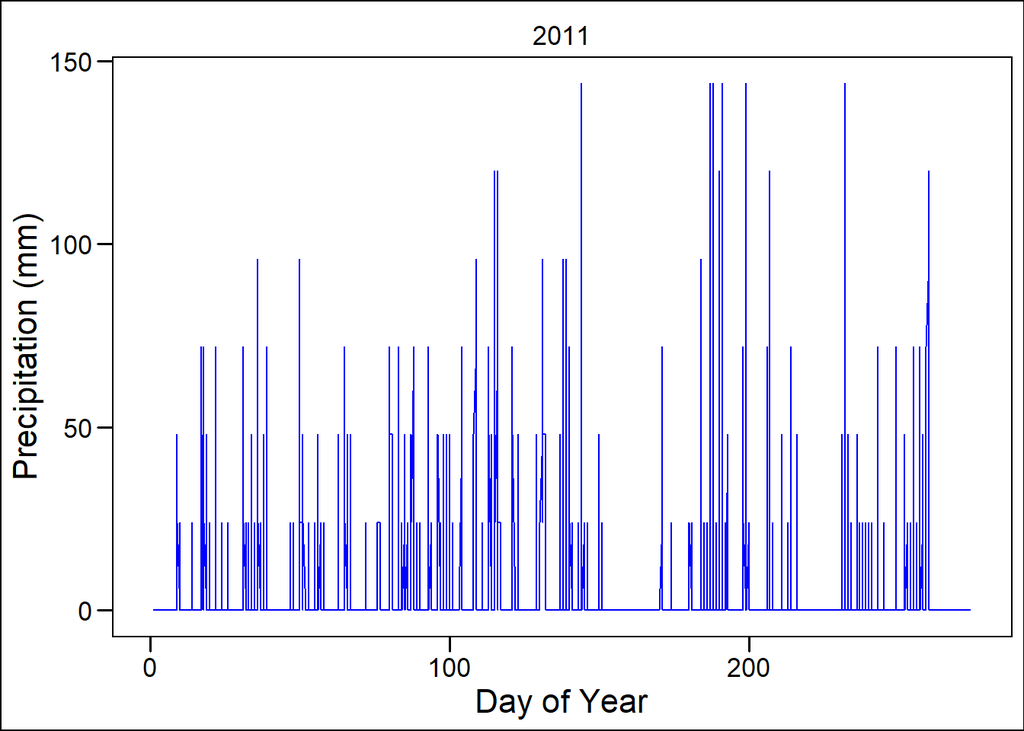

```r
plot_figure_prcp <- function(df, year) {
precip_doy <- df %>%
  mutate(date = make_date(year, month, day)) %>%
  mutate(date = as.Date(date))%>%
  mutate(doy = yday(date)) %>%
  filter(yr == year) %>%
  rename(precip_unit_area = "precip [kg m-2 s-1]") %>%
  mutate(precip_mm = precip_unit_area*86400) %>%
  group_by(doy, year)

figure_prcp <-
 ggplot(precip_doy,aes(x=doy,y=precip_mm)) +
  geom_line(color="blue") +
  theme_base() +
  scale_color_few() +
  labs(x='Day of Year', y="Precipitation (mm)") +
  facet_wrap(~year)

print(figure_prcp)
}

years <- c(2005:2011)

for (yr in years){
  plot_figure_prcp(met_data_full, year)
}
```